# Image Classification- Cassava Leaf Disease

### Comparison of different neural network models using PyTorch

Image classification is a supervised learning problem: define a set of target classes (objects to identify in images), and train a model to recognize them using labelled example photos. [[Source]](https://developers.google.com/machine-learning/practica/image-classification)

Deep learning, a subset of machine learning algorithms, is good at recognising patterns. Hence, it is widely used for image classification. The adjective "deep" in deep learning refers to the use of multiple layers in the network, where each layer progressively extracts higher-level features from the raw input. Deep learning models can have different architectures.

1. Feed Forward Neural Network
2. Convolutional Neural Network
3. Resnet34 pretrained architecture
4. Efficientnet-B4 pretrained architecture
5. Resnext50_32x4d pretrained architecture

The project is inspired from the [Zero to GANs](https://jovian.ai/learn/deep-learning-with-pytorch-zero-to-gans) course by the data science learning platform, [Jovian](https://www.jovian.ai).

## Data exploration

Let us begin by downloading the dataset.

```python
!pip install jovian opendatasets --upgrade --quiet
```

```python
import opendatasets as od
#dataset_url='https://www.kaggle.com/aswiniabraham/cassava-leaf-disease-image-folders-600x800'

dataset_url='https://www.kaggle.com/c/cassava-leaf-disease-classification/data'
od.download(dataset_url)
```

```
Please provide your Kaggle credentials to download this dataset. Learn more: http://bit.ly/kaggle-creds
Your Kaggle username: aswiniabraham
Your Kaggle Key: ········
```

```
Downloading cassava-leaf-disease-classification.zip to ./cassava-leaf-disease-classification
```

```python
%%time
from zipfile import ZipFile

with ZipFile('cassava-leaf-disease-classification/cassava-leaf-disease-classification.zip') as zipper:
    zipper.extractall('./data')
```

```
CPU times: user 26.1 s, sys: 10.6 s, total: 36.7 s
Wall time: 2min 1s
```

```python
import os
import torch
import torchvision
import tarfile
import torch.nn as nn
import numpy as np
import pandas as pd
import torch.nn.functional as F
from torchvision.datasets.utils import download_url
from torchvision.datasets import ImageFolder
from torch.utils.data import DataLoader
import torchvision.transforms as tt
from torch.utils.data import random_split
from torchvision.utils import make_grid
import matplotlib
import matplotlib.pyplot as plt
from torchvision.transforms import ToTensor
%matplotlib inline

matplotlib.rcParams['figure.facecolor'] = '#ffffff'
```

```python
os.listdir('./data')
```

```
['train_images',
 'test_tfrecords',
 'sample_submission.csv',
 'label_num_to_disease_map.json',
 'train.csv',
 'train_tfrecords',
 'test_images']
```

The extracted dataset contains mainly the following folders/files:

1. **train_images:** contains images in jpg format for training
2. **train.csv:** contains the filename of the image and the ID code of the disease.
3. **label_num_to_disease_map.json:** The mapping between each disease code and the real disease name.

```python
images_labels = pd.read_csv('./data/train.csv')
images_labels.head(5)
```

|  | image_id | label |
| --- | --- | --- |
| 0 | 1000015157.jpg | 0 |
| 1 | 1000201771.jpg | 3 |
| 2 | 100042118.jpg | 1 |
| 3 | 1000723321.jpg | 1 |
| 4 | 1000812911.jpg | 3 |

```python
label_map = pd.read_json('./data/label_num_to_disease_map.json', orient='index')
label_map
```

|  | 0 |
| --- | --- |
| 0 | Cassava Bacterial Blight (CBB) |
| 1 | Cassava Brown Streak Disease (CBSD) |
| 2 | Cassava Green Mottle (CGM) |
| 3 | Cassava Mosaic Disease (CMD) |
| 4 | Healthy |

```python
os.listdir('./data/train_images')
```

[output not shown]

[output cut: 946 more lines]

[output not shown]

Since all the training images are present in a single folder, we need to classify them into sub folders such that each folder contains images of its class. This kind of classification will make it possible to use the ImageFolder class of PyTorch.

Let us save the training images into seperate subfolders based on their disease classes. Also, we set aside 10% of images randomly chosen from each class as test images.

## Creating custom PyTorch datatset

```python
os.getcwd()
```

```
'/kaggle/working'
```

```python
base_dir = './data'

train_dir = base_dir + '/train'
os.mkdir(train_dir)
test_dir = base_dir + '/test'
os.mkdir(test_dir)
```

```python
import shutil

c = 0
for i in range(len(images_labels.label.unique())):
    new_dir = train_dir + '/' + label_map.iloc[i].item()
    os.mkdir(new_dir)
    for filename in images_labels[images_labels.label == i]['image_id']:
        for file in os.listdir('./data/train_images'):
            if file == filename:
                shutil.move('./data/train_images/' + file, new_dir + '/' + file)
                c += 1
                if c % 500 == 0:
                    print(f"Moved {c} images.")
                break
#print(f"Moved all {c} images.")
```

[output not shown]

Let us check if the count of images in the subfolders matches with the count of images belonging to that category. This way we can verify if we have moved all the images into the correct subfolders.

```python
images_labels.groupby('label').count()
```

| label | image_id |
| --- | --- |
| 0 | 1087 |
| 1 | 2189 |
| 2 | 2386 |
| 3 | 13158 |
| 4 | 2577 |

```python
class_folders=os.listdir(train_dir)
class_folders
```

```
['Cassava Mosaic Disease (CMD)',
 'Healthy',
 'Cassava Green Mottle (CGM)',
 'Cassava Bacterial Blight (CBB)',
 'Cassava Brown Streak Disease (CBSD)']
```

```python
index=0
for index in range(len(class_folders)):
  print(len(os.listdir(train_dir+'/'+class_folders[index])))
```

```
13158
2577
2386
1087
2189
```

Now, let us craete a test dataset using 10% of random images from each sub-class of the train dataset.

```python
import random
random_seed=42

for folder in class_folders:
  new_dir = test_dir + '/' + folder
  os.mkdir(new_dir)
  files = os.listdir(train_dir + '/' + folder)
  to_move = random.sample(files, int(len(files)*0.1))
  for filename in to_move:
    for file in os.listdir(train_dir + '/' + folder):
      if file == filename:
        shutil.move(train_dir + '/' + folder + '/' + file, new_dir + '/' + file)
        break
```

```python
ls -l
```

```
total 165892
---------- 1 root root      263 Feb 14 22:00 __notebook_source__.ipynb
-rw-r--r-- 1 root root 71000449 Feb 15 01:14 cassava-enetb4.pth
-rw-r--r-- 1 root root  6298853 Feb 15 04:42 cassava-feedfwd.pth
drwxr-xr-x 2 root root     4096 Feb 15 04:59 cassava-leaf-disease-classification/
drwxr-xr-x 4 root root     4096 Feb 15 02:48 cassava-leaf-disease-image-folders-600x800/
-rw-r--r-- 1 root root 92349231 Feb 15 04:02 cassava-resnext50.pth
-rw-r--r-- 1 root root   199534 Feb 15 04:43 cassava_project.ipynb
drwxr-xr-x 8 root root     4096 Feb 15 05:03 data/
```

```python
dataset= ImageFolder('./data',transform=ToTensor())
```

## View some elements of the dataset

Let us picturise a few training images.

```python
def show_example(img, label):
    print('Label: ', dataset.classes[label], "("+str(label)+")")
    plt.imshow(img.permute(1, 2, 0))
```

```
Label:  test (0)
```

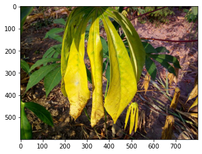

```python
img, label = dataset[0]
show_example(img, label)
```

```python
batch_size=15
data_loader = DataLoader(dataset, batch_size, shuffle=True, num_workers=4, pin_memory=True)
```

```
images.shape: torch.Size([15, 3, 600, 800])
```

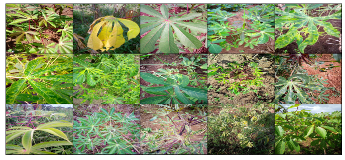

```python
for images, _ in data_loader:
    print('images.shape:', images.shape)
    fig, ax = plt.subplots(figsize=(12, 12))
    ax.set_xticks([]); ax.set_yticks([])
    #denorm_images = denormalize(images, *stats)
    ax.imshow(make_grid(images, nrow=5).permute(1, 2, 0).clamp(0,1))
    break
```

## Prepare dataset for training

In-order to avoid overfitting, we apply the following transformations while loading images from training dataset:

```python
'''def GetStat(data):
  """Function to calculate the mean and std of the input tensors.
  Args:
  Input: ImageFolder containing tensors
  Return: tuple of mean and std
  """
  loader = DataLoader(data,
                         batch_size=batch_size,
                         num_workers=0,
                         shuffle=False)
  mean = 0.
  std = 0.
  for images, _ in loader:
      batch_samples = images.size(0) # batch size (the last batch can have smaller size!)
      images = images.view(batch_samples, images.size(1), -1)
      mean += images.mean(2).sum(0)
      std += images.std(2).sum(0)

  mean /= len(loader.dataset)
  std /= len(loader.dataset)
  mean= mean.numpy()
  std=std.numpy()
  return (mean, std)
stats=GetStat(train_ds)
print(stats)'''
```

```python
# Data transforms (normalization & data augmentation)

stats=((0.43043306, 0.4969931 , 0.3137205 ), (0.21940342, 0.22414596, 0.20117915))

train_tfms = tt.Compose([tt.RandomCrop((128,128), padding=4, padding_mode='reflect'),
                         tt.RandomHorizontalFlip(),
                         #tt.RandomRotation,
                         #tt.RandomResizedCrop(256, scale=(0.5,0.9), ratio=(1.0, 1.0)),
                         tt.ColorJitter(brightness=0.1, contrast=0.1, saturation=0.1, hue=0.1),
                         tt.ToTensor(),
                         tt.Normalize(*stats,inplace=True)])
valid_tfms = tt.Compose([tt.CenterCrop(128),tt.ToTensor(), tt.Normalize(*stats)])
```

```python
# PyTorch datasets
train_ds = ImageFolder('./cassava-leaf-disease-image-folders-600x800/train', train_tfms)
valid_ds = ImageFolder('./cassava-leaf-disease-image-folders-600x800/test', valid_tfms)
```

Define data loaders for training and validation, to load the data in batches.

```python
batch_size=10
```

```python
# PyTorch data loaders
train_dl = DataLoader(train_ds, batch_size, shuffle=True, num_workers=3, pin_memory=True)
valid_dl = DataLoader(valid_ds, batch_size*2, num_workers=3, pin_memory=True)
```

### Base Model Class and Training on GPU

### Base model class

Let's create a base model class, which contains everything except the model architecture i.e. it wil not contain the **init** and **forward** methods. We will later extend this class to try out different architectures.

```python
def accuracy(outputs, labels):
    _, preds = torch.max(outputs, dim=1)
    return torch.tensor(torch.sum(preds == labels).item() / len(preds))

class ImageClassificationBase(nn.Module):
    def training_step(self, batch):
        images, labels = batch
        out = self(images)                  # Generate predictions
        loss = F.cross_entropy(out, labels) # Calculate loss
        return loss

    def validation_step(self, batch):
        images, labels = batch
        out = self(images)                    # Generate predictions
        loss = F.cross_entropy(out, labels)   # Calculate loss
        acc = accuracy(out, labels)           # Calculate accuracy
        return {'val_loss': loss.detach(), 'val_acc': acc}

    def validation_epoch_end(self, outputs):
        batch_losses = [x['val_loss'] for x in outputs]
        epoch_loss = torch.stack(batch_losses).mean()   # Combine losses
        batch_accs = [x['val_acc'] for x in outputs]
        epoch_acc = torch.stack(batch_accs).mean()      # Combine accuracies
        return {'val_loss': epoch_loss.item(), 'val_acc': epoch_acc.item()}

    def epoch_end(self, epoch, result):
        print("Epoch [{}], last_lr: {:.5f}, train_loss: {:.4f}, val_loss: {:.4f}, val_acc: {:.4f}".format(
            epoch, result['lrs'][-1], result['train_loss'], result['val_loss'], result['val_acc']))
```

### Using GPU

To seamlessly use a GPU, if one is available, we define a couple of helper functions (get_default_device & to_device) and a helper class DeviceDataLoader to move our model & data to the GPU as required.

```python
def get_default_device():
    """Pick GPU if available, else CPU"""
    if torch.cuda.is_available():
        return torch.device('cuda')
    else:
        return torch.device('cpu')

def to_device(data, device):
    """Move tensor(s) to chosen device"""
    if isinstance(data, (list,tuple)):
        return [to_device(x, device) for x in data]
    return data.to(device, non_blocking=True)

class DeviceDataLoader():
    """Wrap a dataloader to move data to a device"""
    def __init__(self, dl, device):
        self.dl = dl
        self.device = device

    def __iter__(self):
        """Yield a batch of data after moving it to device"""
        for b in self.dl:
            yield to_device(b, self.device)

    def __len__(self):
        """Number of batches"""
        return len(self.dl)
```

```python
device = get_default_device()
device
```

```
device(type='cuda')
```

Let's move our data loaders to the appropriate device.

```python
train_dl = DeviceDataLoader(train_dl, device)
valid_dl = DeviceDataLoader(valid_dl, device)
```

### Helper functions for plotting loss and accuracy

Let us also define a couple of helper functions for plotting the losses & accuracies.

```python
def plot_losses(history):
    train_losses = [x.get('train_loss') for x in history]
    val_losses = [x['val_loss'] for x in history]
    plt.plot(train_losses, '-bx')
    plt.plot(val_losses, '-rx')
    plt.xlabel('epoch')
    plt.ylabel('loss')
    plt.legend(['Training', 'Validation'])
    plt.title('Loss vs. No. of epochs');
```

```python
def plot_accuracies(history):
    accuracies = [x['val_acc'] for x in history]
    plt.plot(accuracies, '-x')
    plt.xlabel('epoch')
    plt.ylabel('accuracy')
    plt.title('Accuracy vs. No. of epochs');
```

```python
def plot_lrs(history):
    lrs = np.concatenate([x.get('lrs', []) for x in history])
    plt.plot(lrs)
    plt.xlabel('Batch no.')
    plt.ylabel('Learning rate')
    plt.title('Learning Rate vs. Batch no.');
```

### Training loop

We define a fit_one_cycle function for training the model. We do the following processes in the fit_one_cycle function to improve its performance.

- **Learning rate scheduling:** Instead of using a fixed learning rate, we will use a learning rate scheduler, which will change the learning rate after every batch of training. There are many strategies for varying the learning rate during training, and the one we'll use is called the "One Cycle Learning Rate Policy", which involves starting with a low learning rate, gradually increasing it batch-by-batch to a high learning rate for about 30% of epochs, then gradually decreasing it to a very low value for the remaining epochs. [[Source]](https://sgugger.github.io/the-1cycle-policy.html)
- **Weight decay:** We also use weight decay, which is yet another regularization technique which prevents the weights from becoming too large by adding an additional term to the loss function.[[Source]](https://towardsdatascience.com/this-thing-called-weight-decay-a7cd4bcfccab)
- **Gradient clipping:** Apart from the layer weights and outputs, it also helpful to limit the values of gradients to a small range to prevent undesirable changes in parameters due to large gradient values. This simple yet effective technique is called gradient clipping. [[Source]](https://towardsdatascience.com/what-is-gradient-clipping-b8e815cdfb48)

Let's define a fit_one_cycle function now. We'll also record the learning rate used for each batch.

```python
from tqdm.notebook import tqdm

@torch.no_grad()
def evaluate(model, val_loader):
    model.eval()
    outputs = [model.validation_step(batch) for batch in val_loader]
    return model.validation_epoch_end(outputs)

def get_lr(optimizer):
    for param_group in optimizer.param_groups:
        return param_group['lr']

def fit_one_cycle(epochs, max_lr, model, train_loader, val_loader,
                  weight_decay=0, grad_clip=None, opt_func=torch.optim.SGD):
    torch.cuda.empty_cache()
    history = []

    # Set up cutom optimizer with weight decay
    optimizer = opt_func(model.parameters(), max_lr, weight_decay=weight_decay)
    # Set up one-cycle learning rate scheduler
    sched = torch.optim.lr_scheduler.OneCycleLR(optimizer, max_lr, epochs=epochs,
                                                steps_per_epoch=len(train_loader))
                                                  #steps_per_epoch= batches/ epoch
    for epoch in range(epochs):
        # Training Phase
        model.train() #batchnorm layers can train their parameters beta and gamma, dropout can drop 20% of values
        train_losses = []
        lrs = []
        for batch in tqdm(train_loader):
            loss = model.training_step(batch)
            train_losses.append(loss)
            loss.backward()

            # Gradient clipping
            if grad_clip: #if any gradients > set value, hey get clipped
                nn.utils.clip_grad_value_(model.parameters(), grad_clip)

            optimizer.step() # perform gradient descent, add weight decay to loss, derivative for weight decay, perform gradient decsendt
            optimizer.zero_grad()

            # Record & update learning rate
            lrs.append(get_lr(optimizer)) # record lr for each batch
            sched.step() #calc next lr based on one cycle policy

        # Validation phase
        result = evaluate(model, val_loader)
        result['train_loss'] = torch.stack(train_losses).mean().item()
        result['lrs'] = lrs
        model.epoch_end(epoch, result)
        history.append(result)
    return history
```

## Model-1: Feed Forward Neural Networks

```python
input_size= 3*128*128
```

```python
class FeedFwdModel(ImageClassificationBase):
    def __init__(self, input_size,output_size):
        super().__init__()
        self.linear1=nn.Linear(input_size,32)
        self.linear2=nn.Linear(32,32)
        self.linear3=nn.Linear(32,output_size)

    def forward(self, xb):
        # Flatten images into vectors
        out = xb.view(xb.size(0), -1)
        # Apply layers & activation functions
        out=self.linear1(out)
        out=F.relu(out)
        out=self.linear2(out)
        out=F.relu(out)
        out=self.linear3(out)
        out=F.relu(out)
        return out
```

You can now instantiate the model, and move it the appropriate device.

```python
model= to_device(FeedFwdModel(input_size,len(train_ds.classes)), device)
```

```python
history = [evaluate(model, valid_dl)]
history
```

```
[{'val_loss': 1.6378871202468872, 'val_acc': 0.0621495321393013}]
```

```python
epochs = 8
max_lr = 0.01
grad_clip = 0.1
weight_decay = 1e-4
opt_func = torch.optim.Adam
```

```python
%%time
history += fit_one_cycle(epochs, max_lr, model, train_dl, valid_dl,
                             grad_clip=grad_clip,
                             weight_decay=weight_decay,
                             opt_func=opt_func)
```

```
Epoch [0], last_lr: 0.00396, train_loss: 1.6068, val_loss: 1.6045, val_acc: 0.0561
```

```
Epoch [1], last_lr: 0.00936, train_loss: 1.6418, val_loss: 2.7624, val_acc: 0.0654
```

```
Epoch [2], last_lr: 0.00972, train_loss: 1.6118, val_loss: 1.6094, val_acc: 0.0505
```

```
Epoch [3], last_lr: 0.00812, train_loss: 1.7070, val_loss: 1.6094, val_acc: 0.0505
```

```
Epoch [4], last_lr: 0.00556, train_loss: 1.6094, val_loss: 1.6094, val_acc: 0.0505
```

```
Epoch [5], last_lr: 0.00283, train_loss: 1.6338, val_loss: 1.6094, val_acc: 0.0505
```

```
Epoch [6], last_lr: 0.00077, train_loss: 1.6094, val_loss: 1.6094, val_acc: 0.0505
```

```
Epoch [7], last_lr: 0.00000, train_loss: 1.6094, val_loss: 1.6094, val_acc: 0.0505
CPU times: user 1min 39s, sys: 19.8 s, total: 1min 59s
Wall time: 29min 1s
```

```python
train_time='29:01'
```

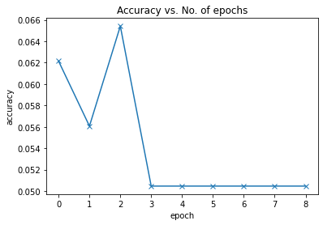

```python
plot_accuracies(history)
```

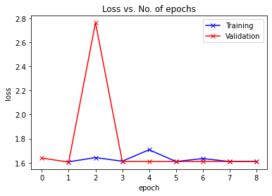

```python
plot_losses(history)
```

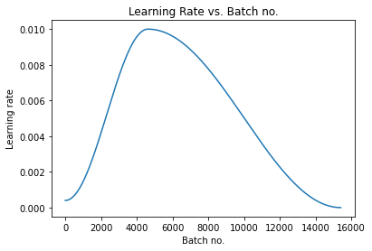

```python
plot_lrs(history)
```

Let us record the hyperparameters and final metrics achieved by the model for reference, analysis and comparison. We can record them using jovian.log_hyperparams.

```python
jovian.reset()
jovian.log_hyperparams(arch='feed forward network',
                       epochs=epochs,
                       lr=max_lr,
                       scheduler='one-cycle',
                       weight_decay=weight_decay,
                       grad_clip=grad_clip,
                       opt=opt_func.__name__)
```

```
[jovian] Hyperparams logged.
```

```python
jovian.log_metrics(val_loss=history[-1]['val_loss'],
                   val_acc=history[-1]['val_acc'],
                   train_loss=history[-1]['train_loss'],
                   time=train_time)
```

```
[jovian] Metrics logged.
```

```python
torch.save(model.state_dict(), 'cassava-feedfwd.pth')
```

```python
jovian.commit(project='cassava_project', environment=None, outputs=['cassava-feedfwd.pth'])
```

```
[jovian] Attempting to save notebook..
[jovian] Detected Kaggle notebook...
[jovian] Uploading notebook to https://jovian.ai/aswiniabraham/cassava_project
```

## Model-2: Convolutional Neural Networks

```python
class CnnModel(ImageClassificationBase):
    def __init__(self, num_classes):
        super().__init__()
        self.network = nn.Sequential(
            nn.Conv2d(3, 32, kernel_size=3, padding=1),
            nn.ReLU(),
            nn.Conv2d(32, 64, kernel_size=3, stride=1, padding=1),
            nn.ReLU(),
            nn.MaxPool2d(2, 2), # output: 64 x 64 x 64

            nn.Conv2d(64, 128, kernel_size=3, stride=1, padding=1),
            nn.ReLU(),
            nn.Conv2d(128, 128, kernel_size=3, stride=1, padding=1),
            nn.ReLU(),
            nn.MaxPool2d(2, 2), # output: 128 x 32 x 32

            nn.Conv2d(128, 256, kernel_size=3, stride=1, padding=1),
            nn.ReLU(),
            nn.Conv2d(256, 256, kernel_size=3, stride=1, padding=1),
            nn.ReLU(),
            nn.MaxPool2d(2, 2), # output: 256 x 16 x 16

            nn.Flatten(),
            nn.Linear(256*16*16, 4096),
            nn.ReLU(),
            nn.Linear(4096, 256),
            nn.ReLU(),
            nn.Linear(256, num_classes))

    def forward(self, xb):
        return self.network(xb)
```

```python
model= CnnModel(len(train_ds.classes))
to_device(model, device)
```

```
CnnModel(
  (network): Sequential(
    (0): Conv2d(3, 32, kernel_size=(3, 3), stride=(1, 1), padding=(1, 1))
    (1): ReLU()
    (2): Conv2d(32, 64, kernel_size=(3, 3), stride=(1, 1), padding=(1, 1))
    (3): ReLU()
    (4): MaxPool2d(kernel_size=2, stride=2, padding=0, dilation=1, ceil_mode=False)
    (5): Conv2d(64, 128, kernel_size=(3, 3), stride=(1, 1), padding=(1, 1))
    (6): ReLU()
    (7): Conv2d(128, 128, kernel_size=(3, 3), stride=(1, 1), padding=(1, 1))
    (8): ReLU()
    (9): MaxPool2d(kernel_size=2, stride=2, padding=0, dilation=1, ceil_mode=False)
    (10): Conv2d(128, 256, kernel_size=(3, 3), stride=(1, 1), padding=(1, 1))
    (11): ReLU()
    (12): Conv2d(256, 256, kernel_size=(3, 3), stride=(1, 1), padding=(1, 1))
    (13): ReLU()
    (14): MaxPool2d(kernel_size=2, stride=2, padding=0, dilation=1, ceil_mode=False)
    (15): Flatten(start_dim=1, end_dim=-1)
    (16): Linear(in_features=65536, out_features=4096, bias=True)
    (17): ReLU()
    (18): Linear(in_features=4096, out_features=256, bias=True)
    (19): ReLU()
    (20): Linear(in_features=256, out_features=5, bias=True)
  )
)
```

```python
history= []
```

```python
history = [evaluate(model, valid_dl)]
history
```

```
[{'val_loss': 1.5846003293991089, 'val_acc': 0.10794392973184586}]
```

```python
epochs = 8
max_lr = 0.01
grad_clip = 0.1
weight_decay = 1e-4
opt_func = torch.optim.Adam
```

```python
%%time
history += fit_one_cycle(epochs, max_lr, model, train_dl, valid_dl,
                             grad_clip=grad_clip,
                             weight_decay=weight_decay,
                             opt_func=opt_func)
```

```
Epoch [0], last_lr: 0.00396, train_loss: 1.1939, val_loss: 1.1860, val_acc: 0.6145
```

```
Epoch [1], last_lr: 0.00936, train_loss: 34.7533, val_loss: 1.1943, val_acc: 0.6145
```

```
Epoch [2], last_lr: 0.00972, train_loss: 16609.8730, val_loss: 1.1914, val_acc: 0.6145
```

```
Epoch [3], last_lr: 0.00812, train_loss: 4.8816, val_loss: 1.1838, val_acc: 0.6145
```

```
Epoch [4], last_lr: 0.00556, train_loss: 1.1995, val_loss: 1.1841, val_acc: 0.6145
```

```
Epoch [5], last_lr: 0.00283, train_loss: 1.1852, val_loss: 1.1838, val_acc: 0.6145
```

```
Epoch [6], last_lr: 0.00077, train_loss: 1.1833, val_loss: 1.1839, val_acc: 0.6145
```

```
Epoch [7], last_lr: 0.00000, train_loss: 1.1834, val_loss: 1.1837, val_acc: 0.6145
CPU times: user 3min 30s, sys: 21.7 s, total: 3min 51s
Wall time: 30min 46s
```

```python
train_time='30:46'
```

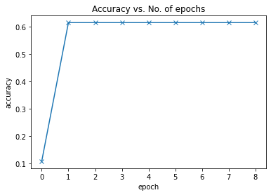

```python
plot_accuracies(history)
```

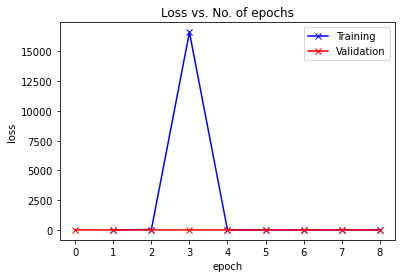

```python
plot_losses(history)
```

Let us record the hyperparameters and final metrics achieved by the model.

```python
jovian.reset()
jovian.log_hyperparams(arch='convolutional neural network',
                       epochs=epochs,
                       lr=max_lr,
                       scheduler='one-cycle',
                       weight_decay=weight_decay,
                       grad_clip=grad_clip,
                       opt=opt_func.__name__)
```

```
[jovian] Hyperparams logged.
```

```python
jovian.log_metrics(val_loss=history[-1]['val_loss'],
                   val_acc=history[-1]['val_acc'],
                   train_loss=history[-1]['train_loss'],
                   time=train_time)
```

```
[jovian] Metrics logged.
```

```python
torch.save(model.state_dict(), 'cnn.pth')
```

```python
jovian.commit(project='cassava_project', environment=None, outputs=['cnn.pth'])
```

```
[jovian] Attempting to save notebook..
[jovian] Detected Kaggle notebook...
[jovian] Uploading notebook to https://jovian.ai/aswiniabraham/cassava_project
```

## Model-3: Resnet34 and transfer learning

```python
# Data transforms (normalization & data augmentation)

imagenet_stats = ([0.485, 0.456, 0.406], [0.229, 0.224, 0.225])
train_tfms = tt.Compose([tt.RandomCrop((128,128), padding=4, padding_mode='reflect'),
                         tt.RandomHorizontalFlip(),
                         #tt.RandomRotation,
                         #tt.RandomResizedCrop(256, scale=(0.5,0.9), ratio=(1.0, 1.0)),
                         tt.ColorJitter(brightness=0.1, contrast=0.1, saturation=0.1, hue=0.1),
                         tt.ToTensor(),
                         tt.Normalize(*imagenet_stats,inplace=True)])
valid_tfms = tt.Compose([tt.CenterCrop(128),tt.ToTensor(), tt.Normalize(*imagenet_stats)])
```

```python
# PyTorch datasets
train_ds = ImageFolder('./cassava-leaf-disease-image-folders-600x800/train', train_tfms)
valid_ds = ImageFolder('./cassava-leaf-disease-image-folders-600x800/test', valid_tfms)
```

```python
batch_size=10
```

```python
# PyTorch data loaders
train_dl = DataLoader(train_ds, batch_size, shuffle=True, num_workers=3, pin_memory=True)
valid_dl = DataLoader(valid_ds, batch_size*2, num_workers=3, pin_memory=True)
```

```python
train_dl = DeviceDataLoader(train_dl, device)
valid_dl = DeviceDataLoader(valid_dl, device)
```

```python
from torchvision import models

class Resnet34Model(ImageClassificationBase):
    def __init__(self, num_classes, pretrained=True):
        super().__init__()
        # Use a pretrained model
        self.network = models.resnet34(pretrained=pretrained)
        # Replace last layer
        self.network.fc = nn.Linear(self.network.fc.in_features, num_classes)

    def forward(self, xb):
        return self.network(xb)
```

```python
model = to_device(Resnet34Model(len(train_ds.classes)), device)
```

```python
history= []
```

```python
history = [evaluate(model, valid_dl)]
history
```

```
[{'val_loss': 1.6652694940567017, 'val_acc': 0.24976633489131927}]
```

```python
epochs = 8
max_lr = 0.01
grad_clip = 0.1
weight_decay = 1e-4
opt_func = torch.optim.Adam
```

```python
%%time
history += fit_one_cycle(epochs, max_lr, model, train_dl, valid_dl,
                             grad_clip=grad_clip,
                             weight_decay=weight_decay,
                             opt_func=opt_func)
```

```
Epoch [0], last_lr: 0.00396, train_loss: 1.2018, val_loss: 1.7423, val_acc: 0.6206
```

```
Epoch [1], last_lr: 0.00936, train_loss: 1.1898, val_loss: 1.2172, val_acc: 0.5972
```

```
Epoch [2], last_lr: 0.00972, train_loss: 1.1844, val_loss: 1.1469, val_acc: 0.6196
```

```
Epoch [3], last_lr: 0.00812, train_loss: 1.1836, val_loss: 1.1837, val_acc: 0.6145
```

```
Epoch [4], last_lr: 0.00556, train_loss: 1.1753, val_loss: 1.0930, val_acc: 0.6248
```

```
Epoch [5], last_lr: 0.00283, train_loss: 1.1428, val_loss: 1.0670, val_acc: 0.6224
```

```
Epoch [6], last_lr: 0.00077, train_loss: 1.1171, val_loss: 1.0275, val_acc: 0.6290
```

```
Epoch [7], last_lr: 0.00000, train_loss: 1.0956, val_loss: 0.9982, val_acc: 0.6352
CPU times: user 16min 30s, sys: 30.2 s, total: 17min
Wall time: 38min 46s
```

```python
train_time='38:46'
```

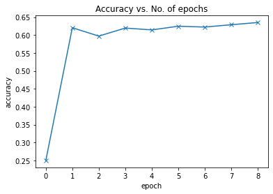

```python
plot_accuracies(history)
```

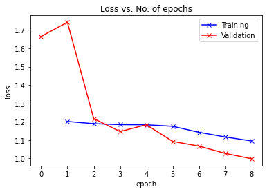

```python
plot_losses(history)
```

Let us record the hyperparameters and final metrics achieved by the model.

```python
jovian.reset()
jovian.log_hyperparams(arch='Resnet34 network',
                       epochs=epochs,
                       lr=max_lr,
                       scheduler='one-cycle',
                       weight_decay=weight_decay,
                       grad_clip=grad_clip,
                       opt=opt_func.__name__)
```

```
[jovian] Hyperparams logged.
```

```python
jovian.log_metrics(val_loss=history[-1]['val_loss'],
                   val_acc=history[-1]['val_acc'],
                   train_loss=history[-1]['train_loss'],
                   time=train_time)
```

```
[jovian] Metrics logged.
```

```python
torch.save(model.state_dict(), 'cassava-resnet34.pth')
```

```python
jovian.commit(project='cassava_project', environment=None, outputs=['cassava-resnet34.pth'])
```

```
[jovian] Attempting to save notebook..
[jovian] Detected Kaggle notebook...
[jovian] Uploading notebook to https://jovian.ai/aswiniabraham/cassava_project
```

## Model-4: EfficientNet B4 model

```python
# Data transforms (normalization & data augmentation)

imagenet_stats = ([0.485, 0.456, 0.406], [0.229, 0.224, 0.225])
train_tfms = tt.Compose([tt.RandomCrop((128,128), padding=4, padding_mode='reflect'),
                         tt.RandomHorizontalFlip(),
                         #tt.RandomRotation,
                         #tt.RandomResizedCrop(256, scale=(0.5,0.9), ratio=(1.0, 1.0)),
                         tt.ColorJitter(brightness=0.1, contrast=0.1, saturation=0.1, hue=0.1),
                         tt.ToTensor(),
                         tt.Normalize(*imagenet_stats,inplace=True)])
valid_tfms = tt.Compose([tt.CenterCrop(128),tt.ToTensor(), tt.Normalize(*imagenet_stats)])
```

```python
# PyTorch datasets
train_ds = ImageFolder('./cassava-leaf-disease-image-folders-600x800/train', train_tfms)
valid_ds = ImageFolder('./cassava-leaf-disease-image-folders-600x800/test', valid_tfms)
```

```python
batch_size=10
```

```python
# PyTorch data loaders
train_dl = DataLoader(train_ds, batch_size, shuffle=True, num_workers=3, pin_memory=True)
valid_dl = DataLoader(valid_ds, batch_size*2, num_workers=3, pin_memory=True)
```

```python
train_dl = DeviceDataLoader(train_dl, device)
valid_dl = DeviceDataLoader(valid_dl, device)
```

```python
! pip install efficientnet-pytorch
```

```python
from efficientnet_pytorch import EfficientNet

class Enetb4Model(ImageClassificationBase):
    def __init__(self, num_classes, pretrained=True):
        super().__init__()
        # Use a pretrained model
        self.network = EfficientNet.from_pretrained('efficientnet-b4', num_classes=num_classes)

    def forward(self, xb):
        return self.network(xb)
```

```python
model = to_device(Enetb4Model(len(train_ds.classes)), device)
```

```python
history= []
```

```python
history = [evaluate(model, valid_dl)]
history
```

[output not shown]

```python
epochs = 8
max_lr = 0.01
grad_clip = 0.1
weight_decay = 1e-4
opt_func = torch.optim.Adam
```

```python
%%time
history += fit_one_cycle(epochs, max_lr, model, train_dl, valid_dl,
                             grad_clip=grad_clip,
                             weight_decay=weight_decay,
                             opt_func=opt_func)
```

[output not shown]

```python
train_time='1:05:57'
```

```python
plot_accuracies(history)
```

[output not shown]

```python
plot_losses(history)
```

[output not shown]

Let us record the hyperparameters and final metrics achieved by the model.

```python
!pip install jovian --upgrade --quiet
```

```python
import jovian
```

```python
jovian.reset()
jovian.log_hyperparams(arch='Effiecientnet B4',
                       epochs=epochs,
                       lr=max_lr,
                       scheduler='one-cycle',
                       weight_decay=weight_decay,
                       grad_clip=grad_clip,
                       opt=opt_func.__name__)
```

```python
jovian.log_metrics(val_loss=history[-1]['val_loss'],
                   val_acc=history[-1]['val_acc'],
                   train_loss=history[-1]['train_loss'],
                   time=train_time)
```

```python
torch.save(model.state_dict(), 'cassava-enetb4.pth')
```

```python
jovian.commit(project='cassava_project', environment=None, outputs=['cassava-enetb4.pth'])
```

```python
os.getcwd()
```

[output not shown]

```python
os.listdir('./')
```

[output not shown]

```python
from IPython.display import FileLink
FileLink(r'cassava-enetb4.pth')
```

## Model-5: Resnext50_32x4d

```python
# ================================================
# resnext50_32x4d architecture
# ================================================

from torchvision import models

class ResnextModel(ImageClassificationBase):
    def __init__(self, num_classes, pretrained=True):
        super().__init__()
        # Use a pretrained model
        self.network = models.resnext50_32x4d(pretrained=pretrained)
        # Replace last layer
        self.network.fc = nn.Linear(self.network.fc.in_features, num_classes)

    def forward(self, xb):
        return self.network(xb)
```

```python
model = ResnextModel(len(train_ds.classes), pretrained= True)
```

```python
to_device(model, device)
```

[output not shown]

[output cut: 123 more lines]

```
      )
      (2): Bottleneck(
        (conv1): Conv2d(2048, 1024, kernel_size=(1, 1), stride=(1, 1), bias=False)
        (bn1): BatchNorm2d(1024, eps=1e-05, momentum=0.1, affine=True, track_running_stats=True)
        (conv2): Conv2d(1024, 1024, kernel_size=(3, 3), stride=(1, 1), padding=(1, 1), groups=32, bias=False)
        (bn2): BatchNorm2d(1024, eps=1e-05, momentum=0.1, affine=True, track_running_stats=True)
        (conv3): Conv2d(1024, 2048, kernel_size=(1, 1), stride=(1, 1), bias=False)
        (bn3): BatchNorm2d(2048, eps=1e-05, momentum=0.1, affine=True, track_running_stats=True)
        (relu): ReLU(inplace=True)
      )
    )
    (avgpool): AdaptiveAvgPool2d(output_size=(1, 1))
    (fc): Linear(in_features=2048, out_features=5, bias=True)
  )
)
```

```python
history= []
```

```python
history = [evaluate(model, valid_dl)]
history
```

```
[{'val_loss': 1.709054946899414, 'val_acc': 0.11039718985557556}]
```

```python
%%time
history += fit_one_cycle(epochs, max_lr, model, train_dl, valid_dl,
                             grad_clip=grad_clip,
                             weight_decay=weight_decay,
                             opt_func=opt_func)
```

```
Epoch [0], last_lr: 0.00396, train_loss: 1.1113, val_loss: 1.0380, val_acc: 0.6275
```

```
Epoch [1], last_lr: 0.00936, train_loss: 1.1528, val_loss: 1.6740, val_acc: 0.6145
```

```
Epoch [2], last_lr: 0.00972, train_loss: 1.1777, val_loss: 1.2194, val_acc: 0.6145
```

```
Epoch [3], last_lr: 0.00812, train_loss: 1.2058, val_loss: 1.1862, val_acc: 0.6145
```

```
Epoch [4], last_lr: 0.00556, train_loss: 1.2107, val_loss: 1.1467, val_acc: 0.6145
```

```
Epoch [5], last_lr: 0.00283, train_loss: 1.1942, val_loss: 1.1059, val_acc: 0.6221
```

```
Epoch [6], last_lr: 0.00077, train_loss: 1.1408, val_loss: 1.0327, val_acc: 0.6341
```

```
Epoch [7], last_lr: 0.00000, train_loss: 1.1161, val_loss: 1.0162, val_acc: 0.6398
CPU times: user 31min 28s, sys: 33.8 s, total: 32min 2s
Wall time: 45min 17s
```

```python
train_time='45:17'
```

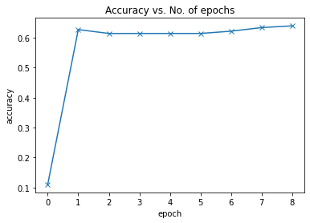

```python
plot_accuracies(history)
```

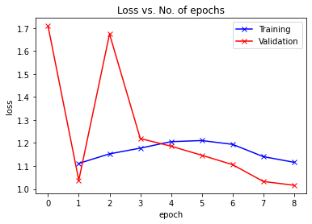

```python
plot_losses(history)
```

Let us record the hyperparameters and final metrics achieved by the model.

```python
jovian.reset()
jovian.log_hyperparams(arch='resnext50_32x4d',
                       epochs=epochs,
                       lr=max_lr,
                       scheduler='one-cycle',
                       weight_decay=weight_decay,
                       grad_clip=grad_clip,
                       opt=opt_func.__name__)
```

```
[jovian] Hyperparams logged.
```

```python
jovian.log_metrics(val_loss=history[-1]['val_loss'],
                   val_acc=history[-1]['val_acc'],
                   train_loss=history[-1]['train_loss'],
                   time=train_time)
```

```
[jovian] Metrics logged.
```

```python
torch.save(model.state_dict(), 'cassava-resnext50.pth')
```

```python
from IPython.display import FileLink
FileLink(r'cassava-resnext50.pth')
```

cassava-resnext50.pth

```python
jovian.commit(project='cassava_project', environment=None, outputs=['cassava-resnext50.pth'])
```

```
[jovian] Attempting to save notebook..
[jovian] Detected Kaggle notebook...
[jovian] Uploading notebook to https://jovian.ai/aswiniabraham/cassava_project
```